# Skorzycka_Julita_8_projekt1

2024-11-20

```r
library(sf)
library(dbscan)
```

```r
library("ggplot2")
```

```r
#Wczytaj plik z geometrią osiedli wraz z punktami do RStudio
osiedla <- st_read("/Users/julitaskorzycka/Desktop/SEMESTR 5/Analiza Danych Przestrzennych /projekt /projekt_analiza-2/osiedla.shp")
dane <- st_read("/Users/julitaskorzycka/Desktop/SEMESTR 5/Analiza Danych Przestrzennych /shapefile/zestaw8_XYTableToPoi_Project2.shp")
# Dopasowanie układów współrzędnych osiedli i punktów
osiedla <- st_transform(osiedla, crs = st_crs(dane))

# Wyodrębnienie współrzędnych punktów
punkty <- st_coordinates(dane)
```

DBSCAN (Density-Based Spatial Clustering of Applications with Noise)

DBSCAN to algorytm, który dzieli dane na klastry w oparciu o gęstość punktów w przestrzeni. Kluczowym założeniem jest to, że klastry tworzą się w obszarach o dużej koncentracji punktów, a obszary o mniejszej liczbie punktów są traktowane jako szum. Algorytm wymaga dwóch parametrów:

1. eps (epsilon): określa maksymalną odległość między dwoma punktami, które mogą należeć do tego samego klastra. Jeśli odległość pomiędzy punktami przekroczy wartość eps, są one traktowane jako oddzielne klastry.
2. minPts: minimalna liczba punktów, które muszą znajdować się w promieniu eps, aby punkt został uznany za część klastra.

Zalety DBSCAN:

- Wykrywa klastry o nieregularnych kształtach, co czyni go skutecznym w analizie złożonych danych przestrzennych.
- Zidentyfikuje punkty szumów, które nie pasują do żadnego klastra, co pomaga w eliminowaniu błędów.
- Algorytm nie wymaga z góry ustalonej liczby klastrów.

Wady DBSCAN:

- Wybór parametrów eps i minPts jest kluczowy i nie zawsze łatwy do określenia, szczególnie w przypadku danych o różnej gęstości.
- Algorytm może mieć trudności z wykrywaniem klastrów, gdy gęstość punktów w różnych częściach danych jest zróżnicowana

```r
# Przeprowadzenie klasteryzacji DBSCAN z różnymi parametrami
dbscan_1 <- dbscan(punkty, eps = 500, minPts = 10)
dbscan_2 <- dbscan(punkty, eps = 250, minPts = 6)
dbscan_3 <- dbscan(punkty, eps = 150, minPts = 3)
dbscan_4 <- dbscan(punkty, eps = 100, minPts = 2)

# Przechowywanie wyników w ramkach danych
wynik_dbscan1 <- data.frame(punkty, cluster = as.factor(dbscan_1$cluster))
wynik_dbscan2 <- data.frame(punkty, cluster = as.factor(dbscan_2$cluster))
wynik_dbscan3 <- data.frame(punkty, cluster = as.factor(dbscan_3$cluster))
wynik_dbscan4 <- data.frame(punkty, cluster = as.factor(dbscan_4$cluster))
```

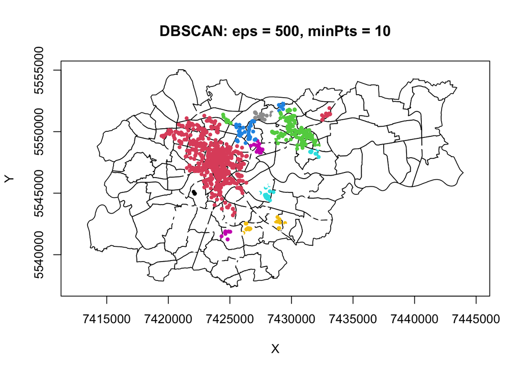

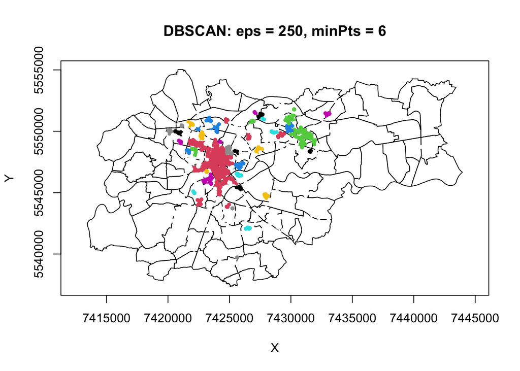

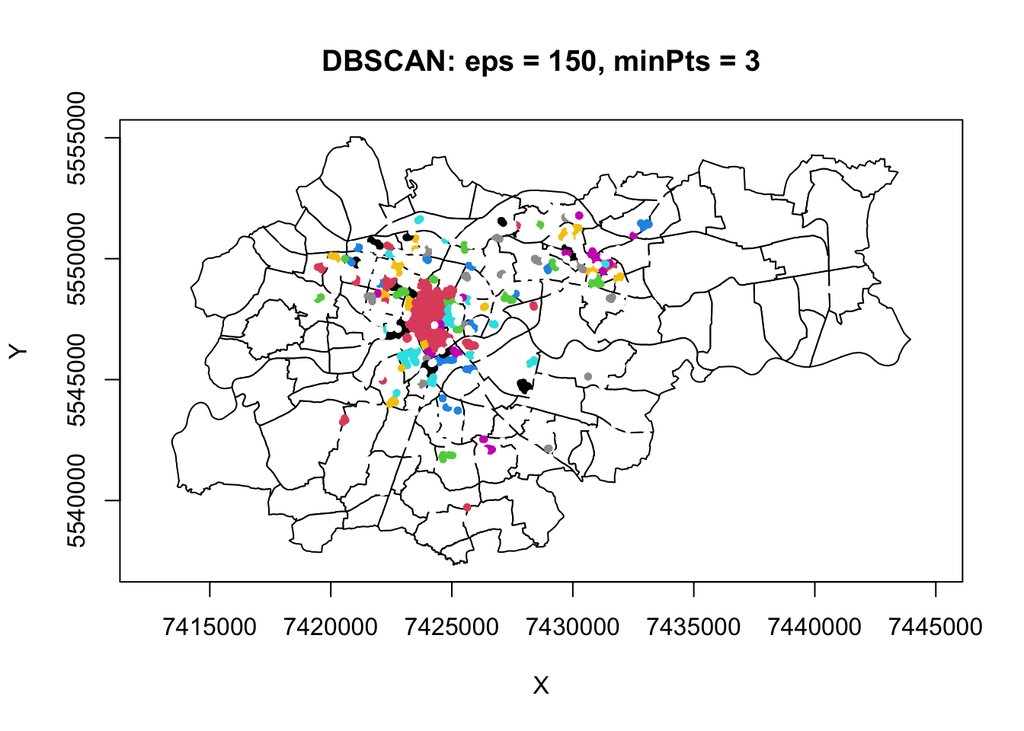

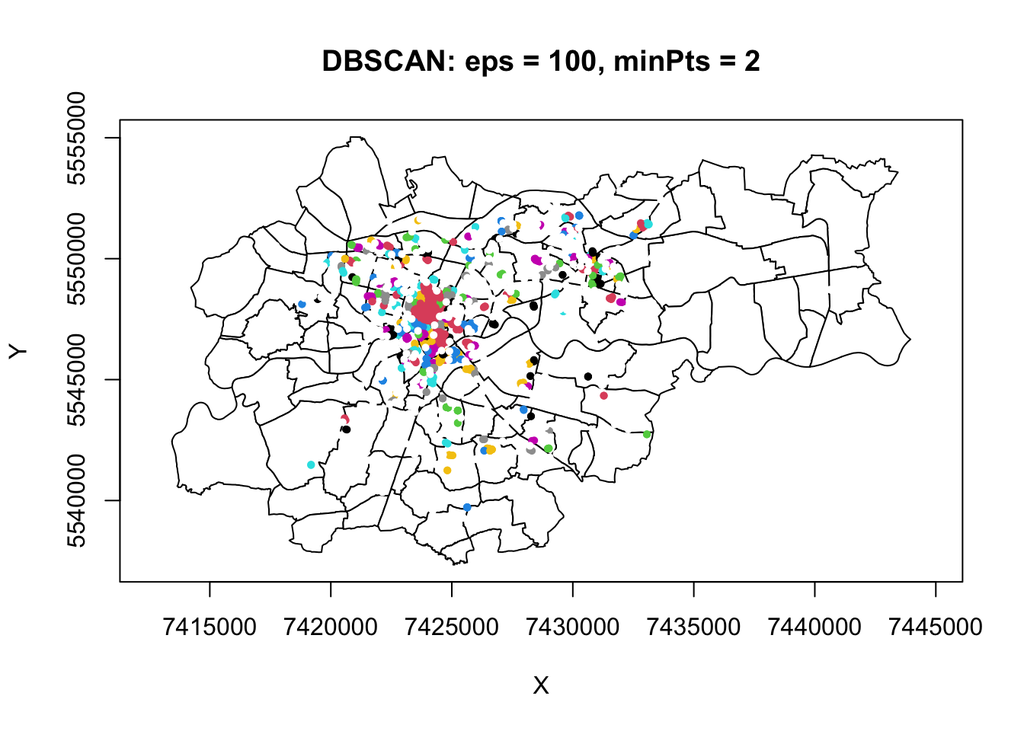

```r
# Tworzenie wykresów dla różnych parametrów DBSCAN
#par(mfrow = c(2, 2))
for (i in 1:4) {
  plot(osiedla$geometry,
       main = paste0("DBSCAN: eps = ", c(500, 250, 150, 100)[i],
                     ", minPts = ", c(10, 6, 3, 2)[i]),
       axes = TRUE,
       xlab = "X",
       ylab = "Y",
       col = "white",
       border = "black")

  # Pobieranie wyników dla odpowiedniego wykresu
  wyniki <- get(paste0("wynik_dbscan", i))

  # Dodawanie punktów dla każdego klastra
  points(wyniki[wyniki[, "cluster"] != 0, 1:2],
         col = wyniki[wyniki[, "cluster"] != 0, "cluster"],  # Kolory klastrów
         pch = 16,
         cex = 0.7)

  # Punkty szumów
  points(wyniki[wyniki[, "cluster"] == 0, 1:2],
         col = "white",  # Białe kropki dla szumów
         pch = 16,
         cex = 0.7)
}
```

Wyniki: DBSCAN

1. Parametry: DBSCAN (eps = 500, minPts = 10)
- Ten wykres pokazuje największe klastry. Duży promień (500) i stosunkowo wysoka liczba punktów (minPts = 10) sprawiają, że wykryte są tylko największe skupiska, ignorując bardziej lokalne zagęszczenia przestępczości.
- Ten wykres identyfikuje głównie większe klastry w centralnych dzielnicach Krakowa. Mniejsze skupiska są uznawane za szum (białe punkty), przez co nie pokazuje on szczegółowych, lokalnych danych.
2. Parametry: DBSCAN (eps = 250, minPts = 6)
- Mniejszy promień (250) i nieco niższy minPts (6) pozwalają na uchwycenie mniejszych klastrów, ale wciąż ignorowane są bardzo lokalne koncentracje przestępczości.
- Wykres pokazuje bardziej zróżnicowane klastry niż poprzedni.
3. Parametry: DBSCAN (eps = 150, minPts = 3)
- Oto wykres, który lepiej radzi sobie z rozpoznawaniem mniejszych klastrów. Mniejszy promień (150) i mniejsze minPts (3) pozwalają uchwycić mniejsze skupiska przestępczości, ale nadal mogą występować błędy w klasyfikacji niektórych punktów.
- Ten wykres zaczyna ukazywać lokalne skupiska przestępczości, co może być pomocne w analizie obszarów o wyższej intensywności przestępstw. Wciąż jednak może być widoczny szum, szczególnie w mniej gęstych częściach Krakowa.
4. Parametry: DBSCAN (eps = 100, minPts = 2)
- Bardzo mały promień (100) i minimalna liczba punktów (2) pozwalają na wykrycie bardzo drobnych skupisk, ale może to także prowadzić do dużej liczby punktów uznanych za szum (zwłaszcza w bardziej rozproszonej przestrzeni).
- Ten wykres identyfikuje drobne skupiska, ale ma również tendencję do traktowania wielu punktów jako szum, zwłaszcza w mniej gęstych częściach Krakowa. Jest bardzo szczegółowy, ale może prowadzić do nieco zafałszowanych wniosków.

/////////////////////////////////////////////////////////////////////////////////

HDBSCAN jest rozszerzeniem algorytmu DBSCAN, które wprowadza dodatkowy etap hierarchicznej klasteryzacji. Główna różnica polega na tym, że HDBSCAN automatycznie dostosowuje parametry klasteryzacji, takie jak gęstość punktów w różnych obszarach, co pozwala mu lepiej radzić sobie z danymi o zmiennej gęstości. Zamiast sztywno ustalać jeden zestaw parametrów, jak w DBSCAN, HDBSCAN może elastycznie dostosowywać minimalną liczbę punktów wymaganych do utworzenia klastra, w zależności od lokalnej gęstości.

Zalety HDBSCAN:

- Adaptacyjność: HDBSCAN jest bardziej elastyczny w porównaniu do DBSCAN, gdyż potrafi wykrywać klastry w danych o zróżnicowanej gęstości, automatycznie dostosowując parametry.
- Wydajność w różnych warunkach: Radzi sobie lepiej z danymi, które mają różne poziomy gęstości, co czyni go bardziej odpowiednim do złożonych zbiorów danych.

Wady HDBSCAN:

- Złożoność obliczeniowa: Proces klasteryzacji w HDBSCAN może być bardziej czasochłonny niż w DBSCAN, zwłaszcza przy dużych zbiorach danych.
- Trudniejsza interpretacja wyników: Ze względu na hierarchiczny charakter algorytmu, wyniki mogą być mniej intuicyjne do analizy niż w przypadku klasycznego DBSCAN.

```r
# Przeprowadzenie klasteryzacji HDBSCAN z różnymi parametrami
hdbscan_1 <- hdbscan(punkty, minPts = 2)
hdbscan_2 <- hdbscan(punkty, minPts = 3)
hdbscan_3 <- hdbscan(punkty, minPts = 5)
hdbscan_4 <- hdbscan(punkty, minPts = 10)

# Przechowywanie wyników HDBSCAN w ramkach danych
wynik_hdbscan1 <- data.frame(punkty, cluster = as.factor(hdbscan_1$cluster))
wynik_hdbscan2 <- data.frame(punkty, cluster = as.factor(hdbscan_2$cluster))
wynik_hdbscan3 <- data.frame(punkty, cluster = as.factor(hdbscan_3$cluster))
wynik_hdbscan4 <- data.frame(punkty, cluster = as.factor(hdbscan_4$cluster))
```

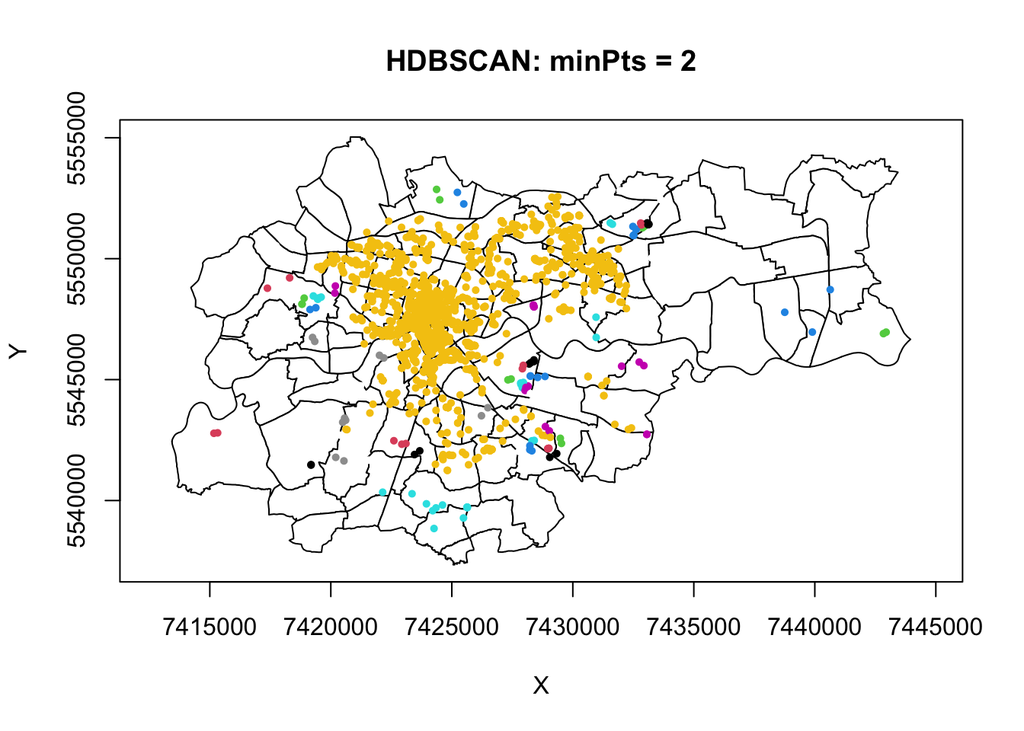

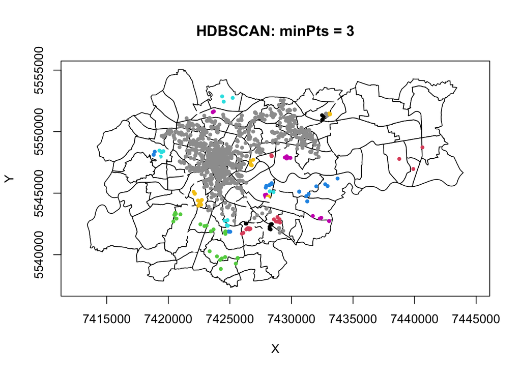

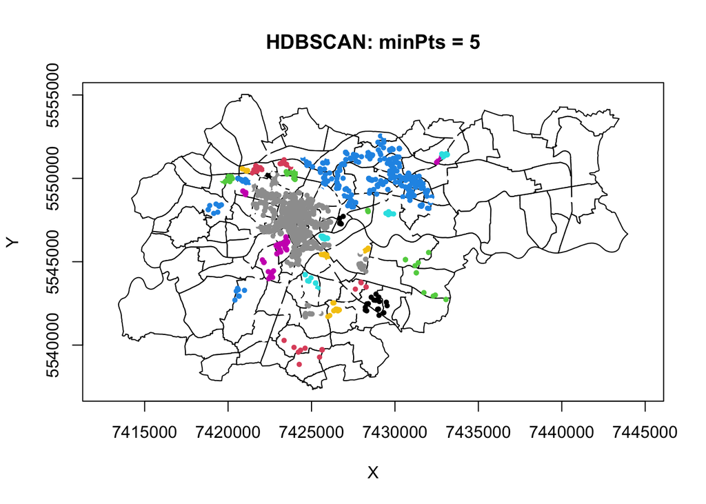

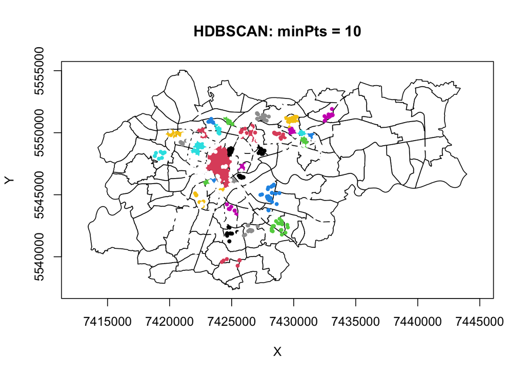

```r
# Tworzenie wykresów dla różnych parametrów HDBSCAN
for (i in 1:4) {
  plot(osiedla$geometry,
       main = paste0("HDBSCAN: minPts = ", c(2, 3, 5, 10)[i]),
       axes = TRUE,
       xlab = "X",
       ylab = "Y",
       col = "white",
       border = "black")

  # Pobieranie wyników dla odpowiedniego wykresu
  wyniki <- get(paste0("wynik_hdbscan", i))

  # Dodawanie punktów dla każdego klastra
  points(wyniki[wyniki[, "cluster"] != 0, 1:2],
         col = wyniki[wyniki[, "cluster"] != 0, "cluster"],  # Kolory klastrów
         pch = 16,
         cex = 0.7)

  # Punkty szumów
  points(wyniki[wyniki[, "cluster"] == 0, 1:2],
         col = "white",  # Białe kropki dla szumów
         pch = 16,
         cex = 0.7)
}
```

//////////////////////////////////////

Wnioski końcowe:

1. Centralnym obszarem przestępczości jest Stare Miasto oraz okolice śródmieścia, co potwierdza zarówno DBSCAN, jak i HDBSCAN.
2. Mniejsze klastry przestępczości można zauważyć na obrzeżach Krakowa, w rejonach takich jak Podgórze, Mistrzejowice, Bieńczyce, czy okolice Krowodrzy.
3. DBSCAN jest bardziej elastyczny w analizie szczegółowej, natomiast HDBSCAN jest bardziej uporządkowany i nadaje się do wyraźnej identyfikacji kluczowych klastrów.
4. Optymalne parametry:
- DBSCAN: eps = 250, minPts = 6.
- HDBSCAN: minPts = 5.